# Disaster Relief Project: Part II

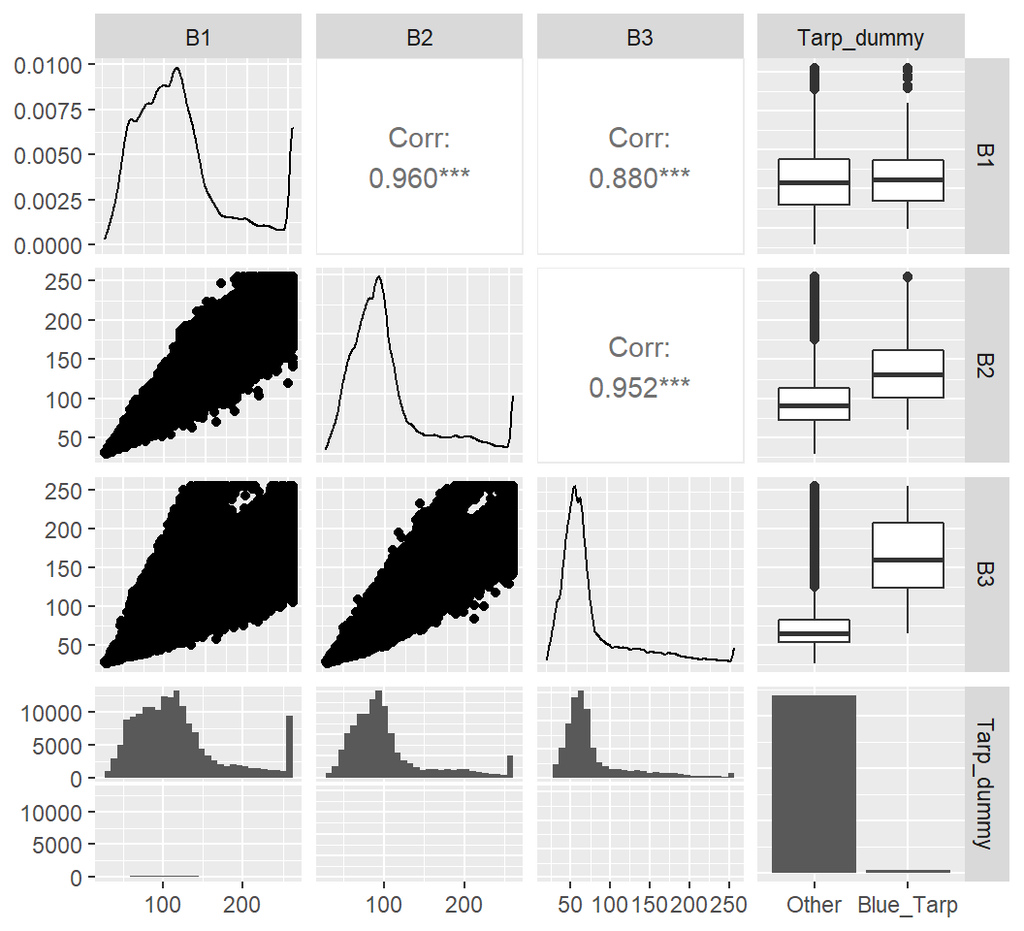

```r
ggpairs(hold_out_data[,2:5])
```

Comparing the two, the boxplot distributions seem to match B1 = Red, B2 = Green & B3 = Blue and relative correlatons, RGB makes the most sense in this context. The boxplots show that Blue has the largest difference between class means, then green, then red for both data sets. Let’s assume that those are the column orders.

```r
names(hold_out_data) <- c("Class","Red","Green","Blue","Tarp_dummy")
head(hold_out_data)
```

```
#>   Class Red Green Blue Tarp_dummy
#> 1 Other 104    89   63      Other
#> 2 Other 103    84   63      Other
#> 3 Other  98    78   57      Other
#> 4 Other  96    69   50      Other
#> 5 Other 115    94   75      Other
#> 6 Other  97    78   63      Other
```

We can also do similar data exploration as we did for the training dataset.

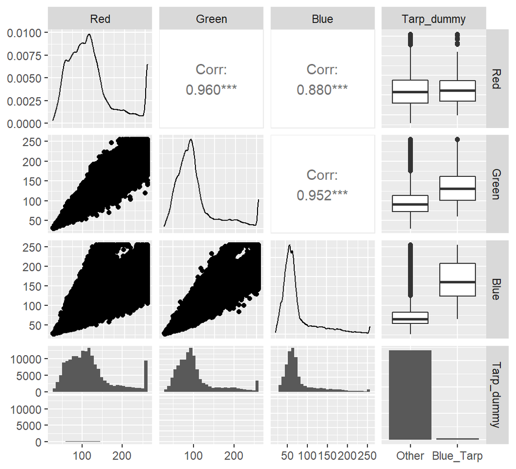

```r
#-- Explore data
ggpairs(hold_out_data[,2:5])
```

From the pairplot, we can see that there a very few blue tarp images in comparison to the Other types of images. As expected, the blue tarps have a certain distribution of pixel values that indicate a blue tarp (average luminosity of red pixels, but high blue and green luminosity values). This is very similar to the data we saw in the training data and will hopefully bode well for prediction on based on the models created from the training data. There does seem to be a more distinct separation on the Blue Pixels for Blue Tarps vs. non-blue tarps. This is interesting and bodes the question could the models be trained solely on the blue pixels alone.

The correlation between blue and red is actually much less for the hold out data compared to the training data. Let’s explore further.

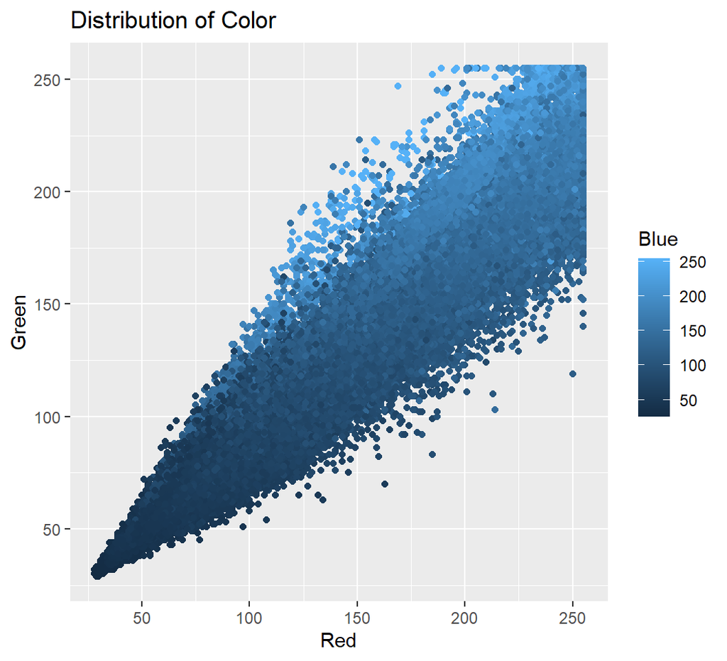

```r
#-- Hue plot
pixelplot<-ggplot() + geom_point(data = hold_out_data, aes(x = Red, y = Green, color = Blue))
print(pixelplot + ggtitle("Distribution of Color"))
```

As seen in the pairplot and confirmed above with a plot of the distribution of color values, the separate color pixel luminosity values are highly correlated for the hold out data just like the trainig data. As red and green luminosity increases, so does blue. It is interesting, though, that it seems that high green and high blue values are more correlated than high red and high blue luminosity (and confirmed in the pairplot) and even more so than the training data.

We can also plot a 3D plot of the data to see the boundary between Blue Tarps and Other Images just like we did before.

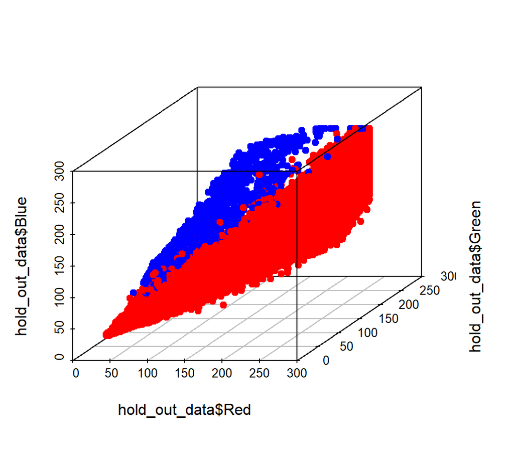

```r
scatterplot3d(x = hold_out_data$Red, y = hold_out_data$Green, z = hold_out_data$Blue,
              color = c("red","blue")[as.factor(hold_out_data$Tarp_dummy)], pch = 19)
```

This plot is interesting because there seems to be less separation in the hold out data than the training data. There are some high levels of blue pixel luminosity that are not blue tarps

# 6 Results (Hold-Out)

Now we can predict on the Hold Out set to see how the trained models on the training set of data performs. The same probability threshold for each model is used as chosen in the training prediction. We also take a look at each of the ROC Curves and the Accuracy of the prediction for each model on the hold out data.

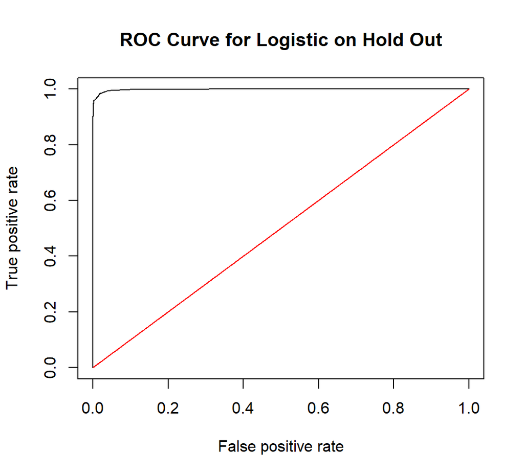

```r
#-- Test and see how it performs on the data
glm.probs.hold_out<- predict(logistic_glm_model_int_red, hold_out_data, type="prob")
rates.glm.hold_out <- prediction(1-glm.probs.hold_out[,2], hold_out_data$Tarp_dummy)
perf.glm.hold_out <- performance(rates.glm.hold_out,"tpr","fpr")

plot(perf.glm.hold_out, main="ROC Curve for Logistic on Hold Out")
lines(x = c(0,1), y = c(0,1), col="red")
```

```r
auc.glm.hold_out <- performance(rates.glm.hold_out, measure = "auc")
auc.glm.hold_out<-auc.glm.hold_out@y.values[[1]]


glm.pred.hold_out<-rep("Other",nrow(hold_out_data))
glm.pred.hold_out[glm.probs.hold_out[,2]>threshold.glm]="Tarp"
glm.hold_out.table<-table(glm.pred.hold_out,hold_out_data$Tarp_dummy)
glm.hold_out.table
```

```
#>
#> glm.pred.hold_out  Other Blue_Tarp
#>             Other 169112       211
#>             Tarp     305      1917
```

```r
mean(glm.pred.hold_out==hold_out_data$Tarp_dummy)
```

```
#> [1] 0.9858171
```

```r
bottom_right.glm.hold_out<-table(glm.pred.hold_out,hold_out_data$Tarp_dummy)[2,2]
bottom_left.glm.hold_out<-table(glm.pred.hold_out,hold_out_data$Tarp_dummy)[2,1]
top_left.glm.hold_out<-table(glm.pred.hold_out,hold_out_data$Tarp_dummy)[1,1]
top_right.glm.hold_out<-table(glm.pred.hold_out,hold_out_data$Tarp_dummy)[1,2]

tpr.glm.hold_out = bottom_right.glm.hold_out/(bottom_right.glm.hold_out+top_right.glm.hold_out)
fpr.glm.hold_out = bottom_left.glm.hold_out/(bottom_left.glm.hold_out+top_left.glm.hold_out)
precision.glm.hold_out = bottom_right.glm.hold_out/(bottom_right.glm.hold_out+bottom_left.glm.hold_out)
accuracy.glm.hold_out = (top_left.glm.hold_out+bottom_right.glm.hold_out)/sum(glm.hold_out.table)
```

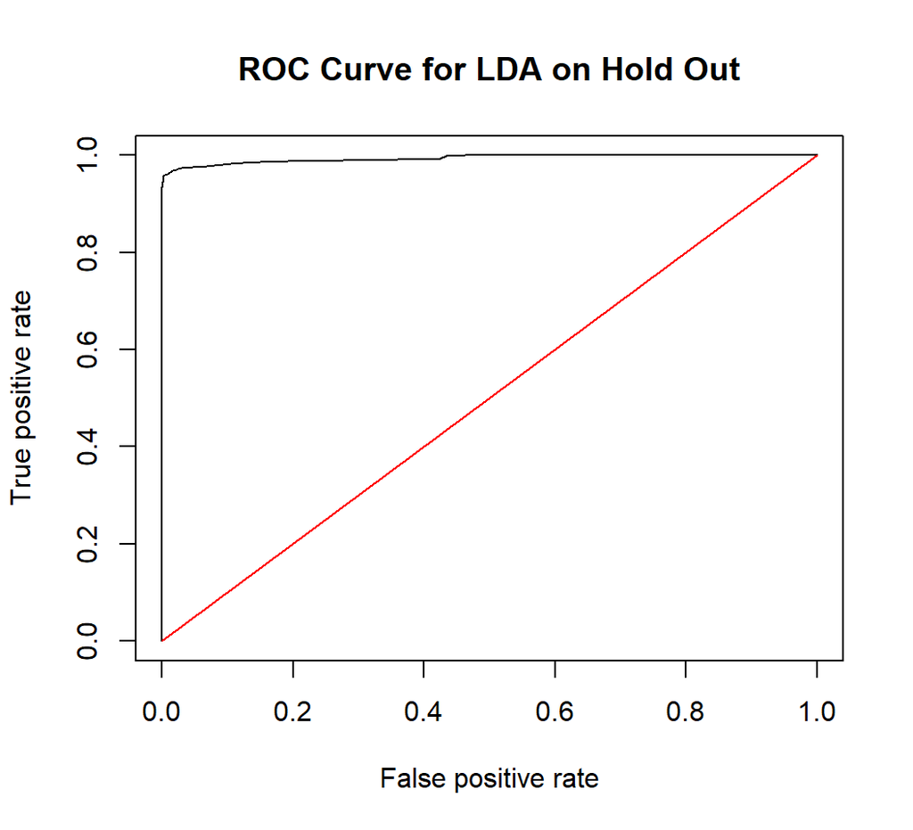

```r
#-- Test and see how it performs on the data
lda.probs.hold_out<- predict(lda_model_no_int, hold_out_data, type="prob")
rates.lda.hold_out <- prediction(1-lda.probs.hold_out[,2], hold_out_data$Tarp_dummy)
perf.lda.hold_out <- performance(rates.lda.hold_out,"tpr","fpr")

plot(perf.lda.hold_out, main="ROC Curve for LDA on Hold Out")
lines(x = c(0,1), y = c(0,1), col="red")
```

```r
auc.lda.hold_out <- performance(rates.lda.hold_out, measure = "auc")
auc.lda.hold_out<-auc.lda.hold_out@y.values[[1]]


lda.pred.hold_out<-rep("Other",nrow(hold_out_data))
lda.pred.hold_out[lda.probs.hold_out[,2]>threshold.lda]="Tarp"
lda.hold_out.table<-table(lda.pred.hold_out,hold_out_data$Tarp_dummy)
lda.hold_out.table
```

```
#>
#> lda.pred.hold_out  Other Blue_Tarp
#>             Other 166796       279
#>             Tarp    2621      1849
```

```r
mean(lda.pred.hold_out==hold_out_data$Tarp_dummy)
```

```
#> [1] 0.9723163
```

```r
bottom_right.lda.hold_out<-table(lda.pred.hold_out,hold_out_data$Tarp_dummy)[2,2]
bottom_left.lda.hold_out<-table(lda.pred.hold_out,hold_out_data$Tarp_dummy)[2,1]
top_left.lda.hold_out<-table(lda.pred.hold_out,hold_out_data$Tarp_dummy)[1,1]
top_right.lda.hold_out<-table(lda.pred.hold_out,hold_out_data$Tarp_dummy)[1,2]

tpr.lda.hold_out = bottom_right.lda.hold_out/(bottom_right.lda.hold_out+top_right.lda.hold_out)
fpr.lda.hold_out = bottom_left.lda.hold_out/(bottom_left.lda.hold_out+top_left.lda.hold_out)
precision.lda.hold_out = bottom_right.lda.hold_out/(bottom_right.lda.hold_out+bottom_left.lda.hold_out)
accuracy.lda.hold_out = (top_left.lda.hold_out+bottom_right.lda.hold_out)/sum(lda.hold_out.table)
```

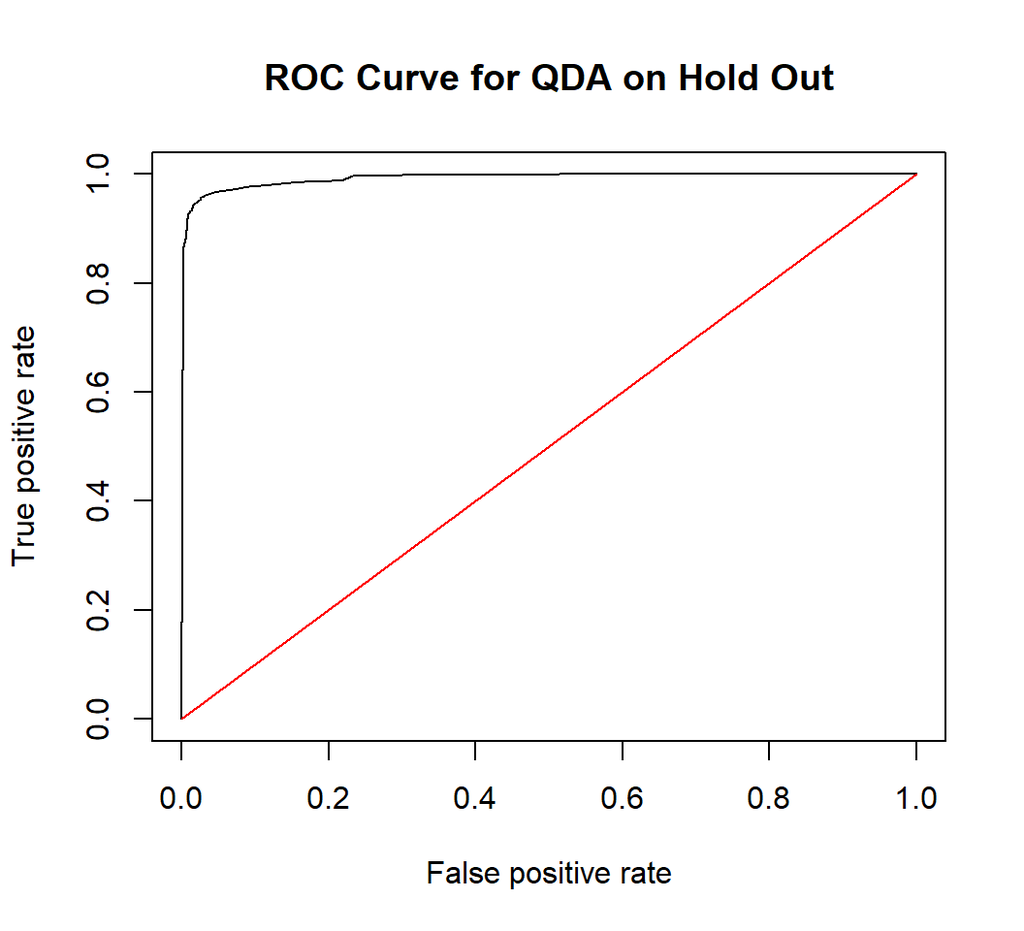

```r
#-- Test and see how it performs on the data
qda.probs.hold_out<- predict(qda_model_no_int, hold_out_data, type="prob")
rates.qda.hold_out <- prediction(1-qda.probs.hold_out[,2], hold_out_data$Tarp_dummy)
perf.qda.hold_out <- performance(rates.qda.hold_out,"tpr","fpr")

plot(perf.qda.hold_out, main="ROC Curve for QDA on Hold Out")
lines(x = c(0,1), y = c(0,1), col="red")
```

```r
auc.qda.hold_out <- performance(rates.qda.hold_out, measure = "auc")
auc.qda.hold_out<-auc.qda.hold_out@y.values[[1]]


qda.pred.hold_out<-rep("Other",nrow(hold_out_data))
qda.pred.hold_out[qda.probs.hold_out[,2]>threshold.qda]="Tarp"
qda.hold_out.table<-table(qda.pred.hold_out,hold_out_data$Tarp_dummy)
qda.hold_out.table
```

```
#>
#> qda.pred.hold_out  Other Blue_Tarp
#>             Other 169206       741
#>             Tarp     211      1387
```

```r
mean(qda.pred.hold_out==hold_out_data$Tarp_dummy)
```

```
#> [1] 0.9863651
```

```r
bottom_right.qda.hold_out<-table(qda.pred.hold_out,hold_out_data$Tarp_dummy)[2,2]
bottom_left.qda.hold_out<-table(qda.pred.hold_out,hold_out_data$Tarp_dummy)[2,1]
top_left.qda.hold_out<-table(qda.pred.hold_out,hold_out_data$Tarp_dummy)[1,1]
top_right.qda.hold_out<-table(qda.pred.hold_out,hold_out_data$Tarp_dummy)[1,2]

tpr.qda.hold_out = bottom_right.qda.hold_out/(bottom_right.qda.hold_out+top_right.qda.hold_out)
fpr.qda.hold_out = bottom_left.qda.hold_out/(bottom_left.qda.hold_out+top_left.qda.hold_out)
precision.qda.hold_out = bottom_right.qda.hold_out/(bottom_right.qda.hold_out+bottom_left.qda.hold_out)
accuracy.qda.hold_out = (top_left.qda.hold_out+bottom_right.qda.hold_out)/sum(qda.hold_out.table)
```

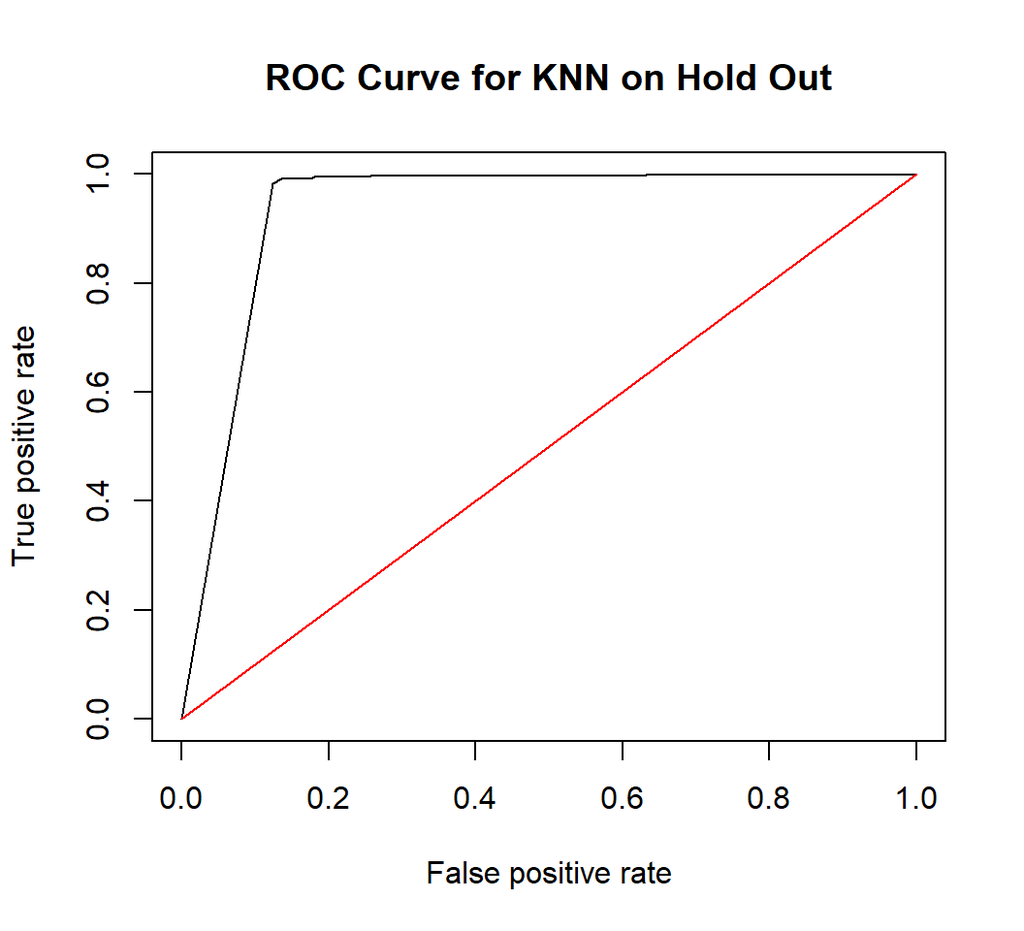

```r
#-- Test and see how it performs on the data
knn.probs.hold_out<- predict(knn_final, hold_out_data, type="prob")
rates.knn.hold_out <- prediction(1-knn.probs.hold_out[,2], hold_out_data$Tarp_dummy)
perf.knn.hold_out <- performance(rates.knn.hold_out,"tpr","fpr")

plot(perf.knn.hold_out, main="ROC Curve for KNN on Hold Out")
lines(x = c(0,1), y = c(0,1), col="red")
```

```r
auc.knn.hold_out <- performance(rates.knn.hold_out, measure = "auc")
auc.knn.hold_out<-auc.knn.hold_out@y.values[[1]]


knn.pred.hold_out<-rep("Other",nrow(hold_out_data))
knn.pred.hold_out[knn.probs.hold_out[,2]>threshold.knn]="Tarp"
knn.hold_out.table<-table(knn.pred.hold_out,hold_out_data$Tarp_dummy)
knn.hold_out.table
```

```
#>
#> knn.pred.hold_out  Other Blue_Tarp
#>             Other 168490       383
#>             Tarp     927      1745
```

```r
mean(knn.pred.hold_out==hold_out_data$Tarp_dummy)
```

```
#> [1] 0.9821913
```

```r
bottom_right.knn.hold_out<-table(knn.pred.hold_out,hold_out_data$Tarp_dummy)[2,2]
bottom_left.knn.hold_out<-table(knn.pred.hold_out,hold_out_data$Tarp_dummy)[2,1]
top_left.knn.hold_out<-table(knn.pred.hold_out,hold_out_data$Tarp_dummy)[1,1]
top_right.knn.hold_out<-table(knn.pred.hold_out,hold_out_data$Tarp_dummy)[1,2]

tpr.knn.hold_out = bottom_right.knn.hold_out/(bottom_right.knn.hold_out+top_right.knn.hold_out)
fpr.knn.hold_out = bottom_left.knn.hold_out/(bottom_left.knn.hold_out+top_left.knn.hold_out)
precision.knn.hold_out = bottom_right.knn.hold_out/(bottom_right.knn.hold_out+bottom_left.knn.hold_out)
accuracy.knn.hold_out = (top_left.knn.hold_out+bottom_right.knn.hold_out)/sum(knn.hold_out.table)
```

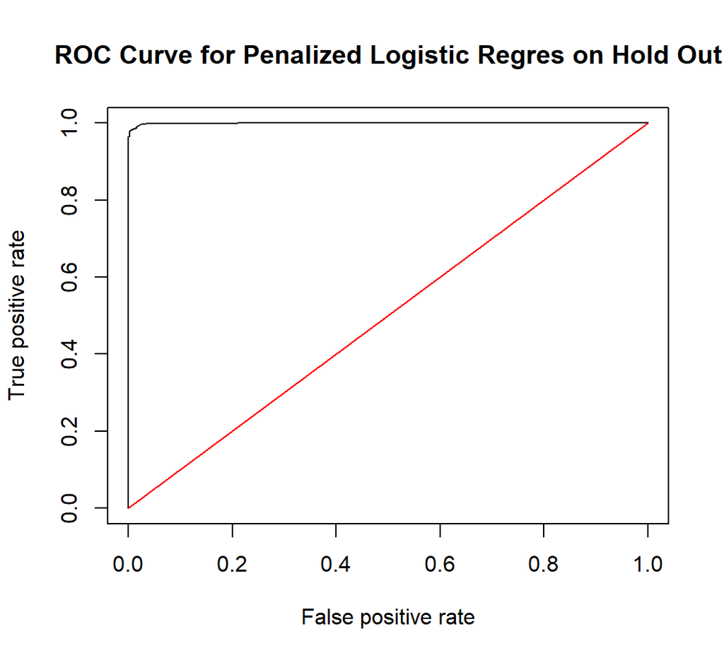

```r
#-- Test and see how it performs on the data
ridge.probs.hold_out<- predict(ridge.fit, hold_out_data, type="prob")
rates.ridge.hold_out <- prediction(1-ridge.probs.hold_out[,2], hold_out_data$Tarp_dummy)
perf.ridge.hold_out <- performance(rates.ridge.hold_out,"tpr","fpr")

plot(perf.ridge.hold_out, main="ROC Curve for Penalized Logistic Regres on Hold Out")
lines(x = c(0,1), y = c(0,1), col="red")
```

```r
auc.ridge.hold_out <- performance(rates.ridge.hold_out, measure = "auc")
auc.ridge.hold_out<-auc.ridge.hold_out@y.values[[1]]


ridge.pred.hold_out<-rep("Other",nrow(hold_out_data))
ridge.pred.hold_out[ridge.probs.hold_out[,2]>threshold.ridge]="Tarp"
ridge.hold_out.table<-table(ridge.pred.hold_out,hold_out_data$Tarp_dummy)
ridge.hold_out.table
```

```
#>
#> ridge.pred.hold_out  Other Blue_Tarp
#>               Other 168948        54
#>               Tarp     469      2074
```

```r
mean(ridge.pred.hold_out==hold_out_data$Tarp_dummy)
```

```
#> [1] 0.9848611
```

```r
bottom_right.ridge.hold_out<-table(ridge.pred.hold_out,hold_out_data$Tarp_dummy)[2,2]
bottom_left.ridge.hold_out<-table(ridge.pred.hold_out,hold_out_data$Tarp_dummy)[2,1]
top_left.ridge.hold_out<-table(ridge.pred.hold_out,hold_out_data$Tarp_dummy)[1,1]
top_right.ridge.hold_out<-table(ridge.pred.hold_out,hold_out_data$Tarp_dummy)[1,2]

tpr.ridge.hold_out = bottom_right.ridge.hold_out/(bottom_right.ridge.hold_out+top_right.ridge.hold_out)
fpr.ridge.hold_out = bottom_left.ridge.hold_out/(bottom_left.ridge.hold_out+top_left.ridge.hold_out)
precision.ridge.hold_out = bottom_right.ridge.hold_out/(bottom_right.ridge.hold_out
                                                        +bottom_left.ridge.hold_out)
accuracy.ridge.hold_out = (top_left.ridge.hold_out+bottom_right.ridge.hold_out)/sum(ridge.hold_out.table)
```

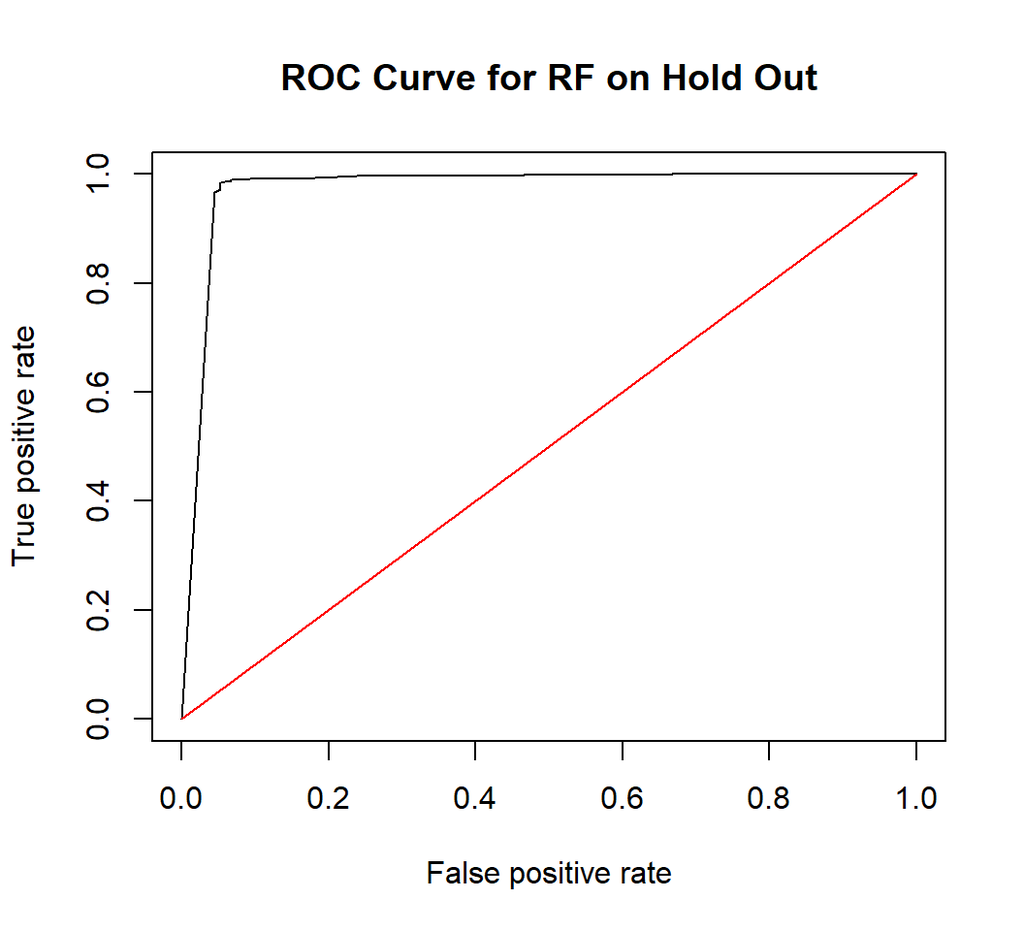

```r
#-- Test and see how it performs on the data
forest.probs.hold_out<- predict(forest.fit, hold_out_data, type="prob")
rates.forest.hold_out <- prediction(1-forest.probs.hold_out[,2], hold_out_data$Tarp_dummy)
perf.forest.hold_out <- performance(rates.forest.hold_out,"tpr","fpr")

plot(perf.forest.hold_out, main="ROC Curve for RF on Hold Out")
lines(x = c(0,1), y = c(0,1), col="red")
```

```r
auc.forest.hold_out <- performance(rates.forest.hold_out, measure = "auc")
auc.forest.hold_out<-auc.forest.hold_out@y.values[[1]]


forest.pred.hold_out<-rep("Other",nrow(hold_out_data))
forest.pred.hold_out[forest.probs.hold_out[,2]>threshold.forest]="Tarp"
forest.hold_out.table<-table(forest.pred.hold_out,hold_out_data$Tarp_dummy)
forest.hold_out.table
```

```
#>
#> forest.pred.hold_out  Other Blue_Tarp
#>                Other 168693       481
#>                Tarp     724      1647
```

```r
mean(forest.pred.hold_out==hold_out_data$Tarp_dummy)
```

```
#> [1] 0.9833746
```

```r
bottom_right.forest.hold_out<-table(forest.pred.hold_out,hold_out_data$Tarp_dummy)[2,2]
bottom_left.forest.hold_out<-table(forest.pred.hold_out,hold_out_data$Tarp_dummy)[2,1]
top_left.forest.hold_out<-table(forest.pred.hold_out,hold_out_data$Tarp_dummy)[1,1]
top_right.forest.hold_out<-table(forest.pred.hold_out,hold_out_data$Tarp_dummy)[1,2]

tpr.forest.hold_out = bottom_right.forest.hold_out/(bottom_right.forest.hold_out+top_right.forest.hold_out)
fpr.forest.hold_out = bottom_left.forest.hold_out/(bottom_left.forest.hold_out+top_left.forest.hold_out)
precision.forest.hold_out = bottom_right.forest.hold_out/(bottom_right.forest.hold_out
                                                          +bottom_left.forest.hold_out)
accuracy.forest.hold_out = (top_left.forest.hold_out+bottom_right.forest.hold_out)/sum(forest.hold_out.table)
```

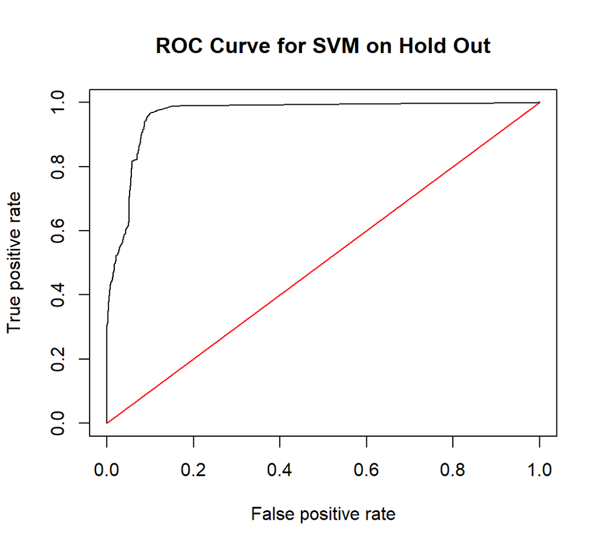

```r
#-- Test and see how it performs on the data
svm.probs.hold_out<- predict(svm.fit.radial, hold_out_data, type="prob")
rates.svm.hold_out <- prediction(1-svm.probs.hold_out[,2], hold_out_data$Tarp_dummy)
perf.svm.hold_out <- performance(rates.svm.hold_out,"tpr","fpr")

plot(perf.svm.hold_out, main="ROC Curve for SVM on Hold Out")
lines(x = c(0,1), y = c(0,1), col="red")
```

```r
auc.svm.hold_out <- performance(rates.svm.hold_out, measure = "auc")
auc.svm.hold_out<-auc.svm.hold_out@y.values[[1]]


svm.pred.hold_out<-rep("Other",nrow(hold_out_data))
svm.pred.hold_out[svm.probs.hold_out[,2]>threshold.svm]="Tarp"
svm.hold_out.table <- table(svm.pred.hold_out,hold_out_data$Tarp_dummy)
svm.hold_out.table
```

```
#>
#> svm.pred.hold_out  Other Blue_Tarp
#>             Other 168593      1258
#>             Tarp     824       870
```

```r
mean(svm.pred.hold_out==hold_out_data$Tarp_dummy)
```

```
#> [1] 0.9827917
```

```r
bottom_right.svm.hold_out<-table(svm.pred.hold_out,hold_out_data$Tarp_dummy)[2,2]
bottom_left.svm.hold_out<-table(svm.pred.hold_out,hold_out_data$Tarp_dummy)[2,1]
top_left.svm.hold_out<-table(svm.pred.hold_out,hold_out_data$Tarp_dummy)[1,1]
top_right.svm.hold_out<-table(svm.pred.hold_out,hold_out_data$Tarp_dummy)[1,2]

tpr.svm.hold_out = bottom_right.svm.hold_out/(bottom_right.svm.hold_out+top_right.svm.hold_out)
fpr.svm.hold_out = bottom_left.svm.hold_out/(bottom_left.svm.hold_out+top_left.svm.hold_out)
precision.svm.hold_out = bottom_right.svm.hold_out/(bottom_right.svm.hold_out+bottom_left.svm.hold_out)
accuracy.svm.hold_out = (top_left.svm.hold_out+bottom_right.svm.hold_out)/sum(svm.hold_out.table)
```

Now that we have all the predictions on the hold out data by each of the Models, we can summarize in a table just like we did for the training data to compare performance on this hold-out test set.

```r
results.hold_out<-data.frame("Model" = c("Log Reg","LDA","QDA","KNN","Penalized Log Reg",
                                         "Random Forest (ntrees=500)","SVM (kernel=Radial)"),
                             "Tuning"= c("n/a","n/a","n/a",best_k,best_lambda,best_mtry,best_cost),
                             "AUROC"=c(0,0,0,0,0,0,0),"Threshold"=c(0,0,0,0,0,0,0),
                             "Accuracy"=c(0,0,0,0,0,0,0),"TPR"=c(0,0,0,0,0,0,0),
                             "FPR"=c(0,0,0,0,0,0,0),"Precision"=c(0,0,0,0,0,0,0))

results.hold_out[,4]=c(threshold.glm, threshold.lda,threshold.qda,
                       threshold.knn,threshold.ridge,threshold.forest,threshold.svm)
results.hold_out[,3]=c(auc.glm.hold_out,auc.lda.hold_out,auc.qda.hold_out,
                       auc.knn.hold_out,auc.ridge.hold_out,auc.forest.hold_out,auc.svm.hold_out)
results.hold_out[,5]=c(accuracy.glm.hold_out,accuracy.lda.hold_out,accuracy.qda.hold_out,
                       accuracy.knn.hold_out,accuracy.ridge.hold_out,accuracy.forest.hold_out
                       ,accuracy.svm.hold_out)
results.hold_out[,6]=c(tpr.glm.hold_out,tpr.lda.hold_out,tpr.qda.hold_out,
                       tpr.knn.hold_out,tpr.ridge.hold_out,tpr.forest.hold_out,tpr.svm.hold_out)
results.hold_out[,7]=c(fpr.glm.hold_out,fpr.lda.hold_out,fpr.qda.hold_out,
                       fpr.knn.hold_out,fpr.ridge.hold_out,fpr.forest.hold_out,fpr.svm.hold_out)
results.hold_out[,8]=c(precision.glm.hold_out,precision.lda.hold_out,precision.qda.hold_out,
                       precision.knn.hold_out,precision.ridge.hold_out,precision.forest.hold_out
                       ,precision.svm.hold_out)


results.hold_out  %>%
  kbl(caption = "Hold-Out Results") %>%
  kable_styling(bootstrap_options = c("striped", "hover", "condensed", "responsive"))
```

Hold-Out Results

| Model | Tuning | AUROC | Threshold | Accuracy | TPR | FPR | Precision |
| --- | --- | --- | --- | --- | --- | --- | --- |
| Log Reg | n/a | 0.9987635 | 0.80 | 0.9969920 | 0.9008459 | 0.0018003 | 0.8627363 |
| LDA | n/a | 0.9935578 | 0.16 | 0.9830948 | 0.8688910 | 0.0154707 | 0.4136465 |
| QDA | n/a | 0.9922695 | 0.76 | 0.9944504 | 0.6517857 | 0.0012454 | 0.8679599 |
| KNN | 3 | 0.9351855 | 0.50 | 0.9923635 | 0.8200188 | 0.0054717 | 0.6530689 |
| Penalized Log Reg | 8.32215451789909e-05 | 0.9995238 | 0.72 | 0.9969512 | 0.9746241 | 0.0027683 | 0.8155722 |
| Random Forest (ntrees=500) | 2 | 0.9743995 | 0.54 | 0.9929756 | 0.7739662 | 0.0042735 | 0.6946436 |
| SVM (kernel=Radial) | 2 | 0.9630707 | 0.68 | 0.9878632 | 0.4088346 | 0.0048637 | 0.5135773 |

# 7 Final Conclusions

## 7.1 Conclusion #1 A discussion of the best performing algorithm(s) in the cross-validation and hold-out data

Compared to previous attempts on the training data alone, the hold out data creates a twist in determining the best performing algorithm on the cross-validation data and the hold data. Taking a look at the performance table on cross-validation, shown below, the K-Nearest Neighbor & Random Forest Models seem to perform the best in predicting which images from the Haitian Earthquake crisis contain Blue Tarps (to assist in identifying temporary shelters).

```r
results %>%
  kbl(caption = "Cross-Validation Results") %>%
  kable_styling(bootstrap_options = c("striped", "hover", "condensed", "responsive"))
```

Cross-Validation Results

| Model | Tuning | AUROC | Threshold | Accuracy | TPR | FPR | Precision |
| --- | --- | --- | --- | --- | --- | --- | --- |
| Log Reg | n/a | 0.9995442 | 0.80 | 0.9949716 | 0.8644906 | 0.0007187 | 0.9754464 |
| LDA | n/a | 0.9888768 | 0.16 | 0.9827802 | 0.8397626 | 0.0124961 | 0.6894032 |
| QDA | n/a | 0.9982175 | 0.76 | 0.9936592 | 0.8046489 | 0.0000980 | 0.9963258 |
| KNN | 3 | 0.9998980 | 0.50 | 0.9981025 | 0.9683482 | 0.0009147 | 0.9721946 |
| Penalized Log Reg | 8.32215451789909e-05 | 0.9985033 | 0.72 | 0.9944024 | 0.8372898 | 0.0004084 | 0.9854482 |
| Random Forest (ntrees=500) | 2 | 0.9944970 | 0.54 | 0.9995889 | 0.9876360 | 0.0000163 | 0.9994995 |
| SVM (kernel=Radial) | 2 | 0.9960265 | 0.68 | 0.9971379 | 0.9371909 | 0.0008821 | 0.9722935 |

In terms of prediction evaluation, both the KNN Model and Random forest performed strongly via cross-validation on the training data set.

[output not shown]

Based on the comparison above, and in terms of cross-validation, it can be determined that the Random Forest Model performed best in terms of predicting which images from the Haitian Earthquake crisis contain Blue Tarps (to assist in identifying temporary shelters) on the cross validation data.

Looking at the hold-out data prediction performance (shown below), the results are a little different than via cross-validation. Note that all of these use the same thresholds as used as in the cross-trained models.

```r
results.hold_out  %>%
  kbl(caption = "Hold-Out Results") %>%
  kable_styling(bootstrap_options = c("striped", "hover", "condensed", "responsive"))
```

Hold-Out Results

| Model | Tuning | AUROC | Threshold | Accuracy | TPR | FPR | Precision |
| --- | --- | --- | --- | --- | --- | --- | --- |
| Log Reg | n/a | 0.9987635 | 0.80 | 0.9969920 | 0.9008459 | 0.0018003 | 0.8627363 |
| LDA | n/a | 0.9935578 | 0.16 | 0.9830948 | 0.8688910 | 0.0154707 | 0.4136465 |
| QDA | n/a | 0.9922695 | 0.76 | 0.9944504 | 0.6517857 | 0.0012454 | 0.8679599 |
| KNN | 3 | 0.9351855 | 0.50 | 0.9923635 | 0.8200188 | 0.0054717 | 0.6530689 |
| Penalized Log Reg | 8.32215451789909e-05 | 0.9995238 | 0.72 | 0.9969512 | 0.9746241 | 0.0027683 | 0.8155722 |
| Random Forest (ntrees=500) | 2 | 0.9743995 | 0.54 | 0.9929756 | 0.7739662 | 0.0042735 | 0.6946436 |
| SVM (kernel=Radial) | 2 | 0.9630707 | 0.68 | 0.9878632 | 0.4088346 | 0.0048637 | 0.5135773 |

## 7.2 Conclusion #2 A discussion or analysis justifying why your findings above are compatible or reconcilable.

The results of the model evaluation on predicting which images from the Haitian Earthquake crisis contain Blue Tarps (to assist in identifying temporary shelters), are reconcilable because any differences between hold-data performance and cross-validation data performance can be explained by how models are trained. Each Model is different in many ways, including its flexibility. Flexibility can be defined as how much is model’s behavior influenced by characteristics of the data; therefore, the flexibility or inflexibility of a model is a characteristic that should not be overlooked. It can mean the difference between a useful or useless Model. Flexible Models fit more easily to the data and put less assumptions on distribution of the data before fitting the Model: in our analysis the most flexible Models are the K-Nearest Neighbor Model, Random Forest, & Support Vector Machines. It is shown that the most flexible Model (KNN), which performs very strongly on cross-validation data (AUROC of 99.98980% ), performs considerably worse on the hold-out data (AUROC of 93.51855% which is the worst). This is due to over-training. The KNN model being the most flexible, especially with a low k value of 3 (number of nearest neighbors to include in the majority of the voting process), fits very closely to the data in the training set. This fit is actually too close and does not allow the model to predict as well on a new data set not in the training set. A similar result is seen in the other flexible models, with Support Vector Machines and Random forest having slightly reduced performance on prediction in the hold out data. This is not as prevalent as the KNN model.

Conversely, the other less flexible models performed similarly in the Hold-Out data as they performed on the cross-validation data. This is expected as they take in more assumptions on how the data actually looks and is distributed and therefore if they perform poorly on the training data (or relatively in terms of this data set) they will likely perform poorly on the hold-out data and visa-versa for the strong performing models. The fact that penalized logistic regression and logistic regression both performed very well on both data sets in terms of prediction might speak about how the data fits well to a logistic regression in general. More investigation could likely be done to investigate the true distribution of the data and this could be featured in future work.

## 7.3 Conclusion #3 A recommendation and rationale regarding which algorithm to use for detection of blue tarps.

As discussed previously, there are significant differences between which models perform the best in terms predicting which images from the Haitian Earthquake crisis contain Blue Tarps (to assist in identifying temporary shelters), on the results of cross-validation on the training data and hold-data. This can be attributed to over-training as discussed above due to flexibility of Models.

## 7.4 Conclusion #4 A discussion of the relevance of the metrics calculated in the tables to this application context.

The metrics used in this analysis for evaluating algorithm performance on predicting which images from the Haitian Earthquake crisis contain Blue Tarps (to assist in identifying temporary shelters) were the following (as seen in the performance tables): AUROC, Accuracy, TPR, FPR and Precision.

[output not shown]

As one can see, all these metrics measure different things. Often, accuracy is used as an indicator of how well a model performs, but it is important to understand this is not an end all be all. Different metrics should be prioritized under different circumstances. In terms of this analysis, it is very important to prioritize predicting the which images contain the blue tarps correctly because the this is a life or death situation. If this is done incorrectly, different areas of Haiti could have been searched instead of the correct areas where survivors are displaced. This incorrect search could waste valuable time in saving lives.

Digging into this further, prioritizing True Positive Rate, False Positive Rate and Precision should be key for this analysis. These metrics deal with how the algorithms perform in correctly predicting which images contain blue tarps. Particularly, Precision, which determines when a Blue Tarp is predicted how often is the prediction correct, seems to be the most relevant. This is because Precision lets the evaluators of the Model determine if the blue tarp predictions can truly be trusted. If the Precision is low, this means the Model poorly predicts blue tarps and if not considered, rescue efforts could be prioritized in incorrect areas of Haiti not containing displaced citizens. Similarly, False Positive Rate and True Positive Rate should be taken into account for similar reasons: ensuring the prediction of blue tarps is as accurate as possible.

Thinking of Precision as a key metric, it is good to see that Penalized Logistic Regression performs strongly for both the cross-validation data and the hold-out data and is one of the main reasons why it is chosen as the top performing algorithm overall.

## 7.5 Conclusion #5: Do you think this analysis could be helpful in saving human lives?

Overall, because all of these algorithms have such strong performance in terms of predicting which images have blue tarps, it is clear that this Modeling could have been very helpful in saving human lives during the Haitian earthquake disaster and during future disasters. If the disaster effort takes pictures like they had done here, as new images were taken, they can be fed into the algorithm to determine which have blue tarps without having to sift through each image one-by-one. The images that are predicted to have blue tarps could be prioritized and searched first to find and save survivors of natural disasters. This would have to be done quickly and efficiently and if a disaster was actually going on, data should be live fed into the Model to save time. Additionally, as mentioned before, if the Model has to be refit and an algorithm other than Penalized Logistic Regression is used with large training time complexity (Random Forest, SVM, KNN, etc.), this time complexity could be an issue depending on the number of images taken. A plan would have to be in place to maximize the area covered with the fewest images.

It is important to note that the Models built here would only be particularly effective when the survivors are using blue tarps as shelter. Otherwise the Models would need to be rebuilt to identify another type of shelter. Maybe the relief effort could airdrop blue tarps so that survivors can find them. This would ensure that these are used and would be identified by the Models.

## 7.6 Conclusion #6: Is the dataset particularly suited for a specific algorithm?

Previously, before Hold-Out Data was added into the analysis, we discussed that imagery data from the Haitian Earthquake disaster seemed to be suited particularly well for prediction via K-Nearest Neighbors. K-Nearest Neighbors Algorithm is one of the most flexible classification method of all of the Models in this analysis, which means it can find much wider range of possible shapes to estimate the data. One of the downfalls of the flexible Models is that they can be more difficult to interpret. In this analysis, the goal is not to interpret the fits, but the most accurately predict where Blue Tarps are to quickly save survivors of the Haitian Earthquake.

With the Hold-Out Data added, this assumption seems to be incorrect; the KNN model performs poorly on the Hold-Out data, while Logistic and Penalized Logistic Regressions performed very well on both Training via cross validation and the hold-out test data. This means that the data is likely strongly suited for a logistic type regression. Logistic regression types perform well when there are a large number of observations and relatively few predictors which is the case in this data set. Additionally, logistic regressions perform well when the data set is linearly separable which could be argued based on the distribution of the data of blue tarps and not as shown in the plots below:

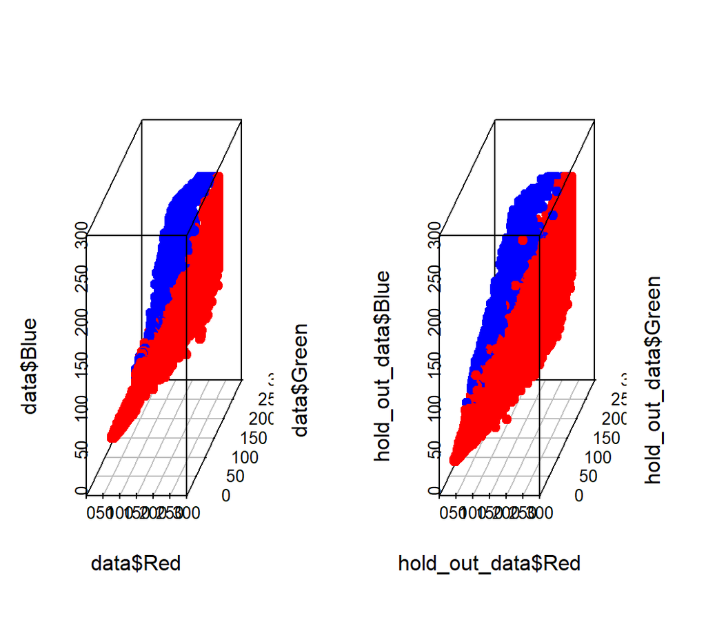

```r
par(mfrow = c(1, 2))
scatterplot3d(x = data$Red, y = data$Green, z = data$Blue,
              color = c("red","blue")[as.factor(data$Tarp_dummy)], pch = 19)
scatterplot3d(x = hold_out_data$Red, y = hold_out_data$Green, z = hold_out_data$Blue,
              color =c("red","blue")[as.factor(hold_out_data$Tarp_dummy)], pch = 19)
```